# Replication Assignment: Developmental constraints in a wild primate

Amanda J. Lea, Jeanne Altmann, Susan C. Alberts, and Jenny Tung

by: Christian Gagnon

```r
library(shiny)
```

Instructions to the assignment can be found [here.](https://fuzzyatelin.github.io/bioanth-stats/data-reanalysis-assignment.html)

## Packages:

The following packages must be installed in order to complete this module:

- {curl}
- {lme4}
- {shiny}
- {car}
- {broom}
- {dplyr}

## Abstract:

In this study, the authors investigated the ways in which environmental conditions affect development in female baboons (*Papio cynocephalus*). According to the predictive adaptive response hypothesis outlined in the article, environmental challenges during early development should result in adaptive adjustments to prepare the individual for similarly harsh future conditions. In the contending, developmental constraint hypothesis, the cost of early adversity is greater than the potential future benefits. This study aims to determine which of these two hypotheses is supported. To get at this question, they collected long-term data on two sets of female baboons in Amboseli, Kenya. The first set were females born in the dry season when food availability was low. While the other group benefited from being born during productive years when rainfall was above average. For each subject they measured and recorded fertility related variables including: age, rank, group size, time since last birth, whether females were cycling or pregnant, and loss of infant. They then used linear mixed modeling to test the relationship between early environment and the previously mentioned covariates. The findings lend support for the developmental constraint hypothesis as females who faced greater challenges early in life had overall lower reproductive success during drought periods than females born in more prosperous years. They also recognized that the offspring of high ranking females were more resilient to decreases in fertility during droughts, regardless of their early environment.They interpret these findings as suggesting that poor conditions during early development having long term detrimental reproductive ramifications.

## Replication

### Loading in the data

Before we begin we will need to load in our data which was obtained [here.](https://datadryad.org/stash/dataset/doi:10.5061/dryad.5r37g)

```r
library(curl)
f <- curl("https://raw.githubusercontent.com/cmgagnon/cmgagnon-data-replication-assignment/master/dev_constraints_dryad_dataset.csv")
d <- read.csv(f, header = TRUE, sep = ",", stringsAsFactors = TRUE)
head(d)
```

```
##   ID maternal_rank early_ecology current_ecology   age rank grp_size
## 1  3             5            HQ              HQ  6.41    9       72
## 2  3             5            HQ               D 10.42    4       92
## 3  3             5            HQ              HQ 12.42    5       26
## 4  5             4            HQ              HQ  6.58    9       58
## 5  5             4            HQ              HQ  7.58   10       60
## 6  5             4            HQ              HQ  9.58   11       72
##   time_since_birth cycling_at_start preg_at_start resumed_cycling
## 1              121                0             N               Y
## 2               92                0             N               N
## 3              119                0             N               N
## 4              112                0             N               N
## 5              477                1             N               Y
## 6              378                0             N               Y
##   conceived infant_death
## 1         N            N
## 2         N            N
## 3         N            N
## 4         N            N
## 5         Y            N
## 6         Y            N
```

```r
summary(d)
```

```
##        ID         maternal_rank   early_ecology current_ecology
##  Min.   :  3.00   Min.   : 1.00   HQ:125        D : 50
##  1st Qu.: 31.25   1st Qu.: 4.00   LQ: 47        HQ:122
##  Median : 50.50   Median : 5.00
##  Mean   : 54.28   Mean   : 7.68
##  3rd Qu.: 83.00   3rd Qu.:10.00
##  Max.   :101.00   Max.   :21.00
##       age              rank         grp_size      time_since_birth
##  Min.   : 5.400   Min.   : 1.0   Min.   : 22.00   Min.   :   6.00
##  1st Qu.: 8.095   1st Qu.: 4.0   1st Qu.: 57.00   1st Qu.:  77.25
##  Median :10.310   Median : 9.0   Median : 72.00   Median : 180.00
##  Mean   :11.376   Mean   :10.1   Mean   : 69.74   Mean   : 261.49
##  3rd Qu.:13.727   3rd Qu.:15.0   3rd Qu.: 80.00   3rd Qu.: 389.25
##  Max.   :24.920   Max.   :28.0   Max.   :113.00   Max.   :2493.00
##  cycling_at_start preg_at_start resumed_cycling conceived infant_death
##  Min.   :0.0000   N:144         N:97            N:87      N:153
##  1st Qu.:0.0000   Y: 28         Y:75            Y:85      Y: 19
##  Median :0.0000
##  Mean   :0.2791
##  3rd Qu.:1.0000
##  Max.   :1.0000
```

```r
str(d)
```

```
## 'data.frame':    172 obs. of  13 variables:
##  $ ID              : int  3 3 3 5 5 5 5 5 12 12 ...
##  $ maternal_rank   : int  5 5 5 4 4 4 4 4 6 6 ...
##  $ early_ecology   : Factor w/ 2 levels "HQ","LQ": 1 1 1 1 1 1 1 1 1 1 ...
##  $ current_ecology : Factor w/ 2 levels "D","HQ": 2 1 2 2 2 2 1 2 1 2 ...
##  $ age             : num  6.41 10.42 12.42 6.58 7.58 ...
##  $ rank            : int  9 4 5 9 10 11 6 2 16 9 ...
##  $ grp_size        : int  72 92 26 58 60 72 92 75 92 75 ...
##  $ time_since_birth: int  121 92 119 112 477 378 531 212 111 130 ...
##  $ cycling_at_start: int  0 0 0 0 1 0 0 1 0 0 ...
##  $ preg_at_start   : Factor w/ 2 levels "N","Y": 1 1 1 1 1 1 2 1 1 1 ...
##  $ resumed_cycling : Factor w/ 2 levels "N","Y": 2 1 1 1 2 2 1 2 2 2 ...
##  $ conceived       : Factor w/ 2 levels "N","Y": 1 1 1 1 2 2 1 2 1 2 ...
##  $ infant_death    : Factor w/ 2 levels "N","Y": 1 1 1 1 1 1 1 2 1 1 ...
```

```r
d
```

[output not shown]

[output cut: 504 more lines]

### Data Visualization

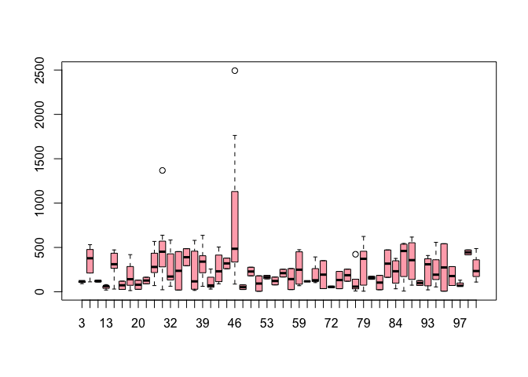

```r
# first, some exploratory visualization let's plot time since giving birth (days) in relation to subject ID
par(mfrow = c(1, 1))
boxplot(data = d, time_since_birth ~ ID, col = c("lightpink1"))
```

So clearly there is a significant amount of variation in days since giving birth but without accounting for other variables this isn’t very helpful.

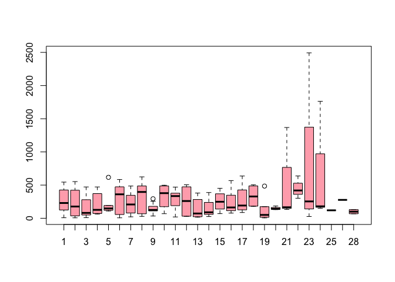

```r
# now let's see how this relates to social rank
par(mfrow = c(1, 1))
boxplot(data = d, time_since_birth ~ rank, col = c("lightpink1"))
```

According to the plot, the lowest ranking individuals seem to have longest inter-birth intervals.

## Generalized Linear Mixed Modeling

### Within-Female Analyses: Interaction between Early-Life

and Adult Conditions on Female Fertility

Now let’s load the package necessary to conduct our mixed effect modeling.

```r
library(lme4)
```

First, let’s do some modeling using the binary “conceived” variable to see if we can replicate their results.

They state in the paper that they used the lmer wrapper function but their table of result say “Results of Generalized Linear Mixed Models” so I think they used the glmer wrapper so thats what I will use. In this model all varialble listed have an additive effect:

```r
glme1 <- glmer(data = d, as.numeric(as.factor(d$conceived)) ~ early_ecology + current_ecology + age + rank + grp_size + time_since_birth + infant_death + preg_at_start + (early_ecology * current_ecology) + (1|ID), REML=FALSE)
summary(glme1)
```

```
## Linear mixed model fit by maximum likelihood  ['lmerMod']
## Formula:
## as.numeric(as.factor(d$conceived)) ~ early_ecology + current_ecology +
##     age + rank + grp_size + time_since_birth + infant_death +
##     preg_at_start + (early_ecology * current_ecology) + (1 |      ID)
##    Data: d
##
##      AIC      BIC   logLik deviance df.resid
##    200.0    237.8    -88.0    176.0      160
##
## Scaled residuals:
##      Min       1Q   Median       3Q      Max
## -2.22115 -0.85276  0.09459  0.83538  1.97460
##
## Random effects:
##  Groups   Name        Variance Std.Dev.
##  ID       (Intercept) 0.01275  0.1129
##  Residual             0.15162  0.3894
## Number of obs: 172, groups:  ID, 50
##
## Fixed effects:
##                                     Estimate Std. Error t value
## (Intercept)                        1.9227947  0.1525243  12.606
## early_ecologyLQ                   -0.0801195  0.1295022  -0.619
## current_ecologyHQ                  0.0997718  0.0823880   1.211
## age                               -0.0110982  0.0080800  -1.374
## rank                              -0.0076910  0.0056550  -1.360
## grp_size                          -0.0053851  0.0016344  -3.295
## time_since_birth                   0.0003171  0.0001271   2.495
## infant_deathY                      0.5354720  0.1034522   5.176
## preg_at_startY                    -0.5980108  0.0942762  -6.343
## early_ecologyLQ:current_ecologyHQ  0.2670554  0.1495642   1.786
##
## Correlation of Fixed Effects:
##             (Intr) erl_LQ crr_HQ age    rank   grp_sz tm_sn_ infn_Y prg__Y
## erly_clgyLQ -0.178
## crrnt_clgHQ -0.571  0.383
## age         -0.387 -0.010 -0.056
## rank        -0.040 -0.033 -0.010 -0.073
## grp_size    -0.633 -0.061  0.283 -0.107 -0.386
## tm_snc_brth  0.049  0.129  0.086 -0.312 -0.136 -0.045
## infant_dthY  0.131 -0.010 -0.022 -0.179  0.132 -0.152 -0.021
## prg_t_strtY -0.238 -0.128  0.066 -0.002  0.152  0.197 -0.323 -0.161
## erly_LQ:_HQ  0.168 -0.797 -0.502  0.048  0.065 -0.024 -0.108 -0.030  0.122
```

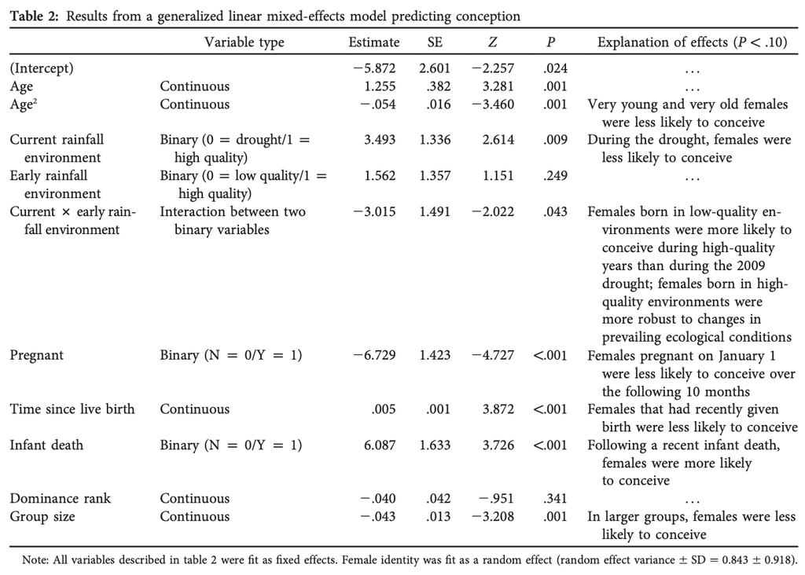

After trying several models I still cannot get my numbers to match theirs. Maybe they messed around with some parameters that I couldn’t figure out. After a little more digging, it looks like I might need to specify the family of error. In the article they say they used a binomial error with a logit link function. Not sure I fully understand what this does but I believe it allows the glmer wrapper to model binary outcomes (i.e. conveived/did not conceive).

```r
glme1a <- glmer(data = d, conceived ~ early_ecology + current_ecology + age + rank + grp_size + time_since_birth + infant_death + preg_at_start + (early_ecology * current_ecology) + (1|ID), family=binomial(link = "logit"))
summary(glme1a)
```

```
## Generalized linear mixed model fit by maximum likelihood (Laplace
##   Approximation) [glmerMod]
##  Family: binomial  ( logit )
## Formula:
## conceived ~ early_ecology + current_ecology + age + rank + grp_size +
##     time_since_birth + infant_death + preg_at_start + (early_ecology *
##     current_ecology) + (1 | ID)
##    Data: d
##
##      AIC      BIC   logLik deviance df.resid
##    180.0    214.6    -79.0    158.0      161
##
## Scaled residuals:
##     Min      1Q  Median      3Q     Max
## -3.8459 -0.5191 -0.0200  0.5636  3.6110
##
## Random effects:
##  Groups Name        Variance Std.Dev.
##  ID     (Intercept) 0.3749   0.6123
## Number of obs: 172, groups:  ID, 50
##
## Fixed effects:
##                                     Estimate Std. Error z value Pr(>|z|)
## (Intercept)                        3.0299781  1.1761250   2.576 0.009988
## early_ecologyLQ                   -1.3253407  1.1824923  -1.121 0.262372
## current_ecologyHQ                  0.5486503  0.5570044   0.985 0.324623
## age                               -0.0625559  0.0584288  -1.071 0.284334
## rank                              -0.0315673  0.0375391  -0.841 0.400394
## grp_size                          -0.0413620  0.0131004  -3.157 0.001592
## time_since_birth                   0.0017830  0.0007951   2.242 0.024937
## infant_deathY                      5.1734066  1.3994747   3.697 0.000218
## preg_at_startY                    -5.2494646  1.2489108  -4.203 2.63e-05
## early_ecologyLQ:current_ecologyHQ  2.6901210  1.3525722   1.989 0.046713
##
## (Intercept)                       **
## early_ecologyLQ
## current_ecologyHQ
## age
## rank
## grp_size                          **
```

[output cut: 9 more lines]

```
## erly_clgyLQ -0.259
## crrnt_clgHQ -0.462  0.330
## age         -0.455  0.038 -0.122
## rank        -0.056 -0.045 -0.021 -0.059
## grp_size    -0.741  0.110  0.218  0.061 -0.285
## tm_snc_brth  0.172  0.081  0.127 -0.389 -0.169 -0.138
## infant_dthY  0.252 -0.094  0.070 -0.191  0.043 -0.294  0.094
## prg_t_strtY -0.370  0.081  0.024  0.141  0.081  0.374 -0.246 -0.686
## erly_LQ:_HQ  0.366 -0.879 -0.414 -0.081  0.052 -0.263 -0.016  0.157 -0.176
## convergence code: 0
## Model failed to converge with max|grad| = 0.164964 (tol = 0.001, component 1)
## Model is nearly unidentifiable: very large eigenvalue
##  - Rescale variables?
## Model is nearly unidentifiable: large eigenvalue ratio
##  - Rescale variables?
```

Still does not look right and I am getting errors about eigen values being too high. I believe this means the model is over fitted but I am using the same variable they did.

Actually, I wasn’t! I will add age as a quadratic effect and see if that does the trick.

```r
glme1b <- glmer(data = d, conceived ~ early_ecology + current_ecology + age + I(age^2) + rank + grp_size + time_since_birth + infant_death + preg_at_start + (early_ecology * current_ecology) + (1|ID), family=binomial(link = "logit"))
summary(glme1b)
```

```
## Generalized linear mixed model fit by maximum likelihood (Laplace
##   Approximation) [glmerMod]
##  Family: binomial  ( logit )
## Formula: conceived ~ early_ecology + current_ecology + age + I(age^2) +
##     rank + grp_size + time_since_birth + infant_death + preg_at_start +
##     (early_ecology * current_ecology) + (1 | ID)
##    Data: d
##
##      AIC      BIC   logLik deviance df.resid
##    167.7    205.5    -71.9    143.7      160
##
## Scaled residuals:
##      Min       1Q   Median       3Q      Max
## -2.75075 -0.39098 -0.01453  0.45074  3.06974
##
## Random effects:
##  Groups Name        Variance Std.Dev.
##  ID     (Intercept) 0.8614   0.9281
## Number of obs: 172, groups:  ID, 50
##
## Fixed effects:
##                                    Estimate Std. Error z value Pr(>|z|)
## (Intercept)                       -4.016041   2.386224  -1.683 0.092373
## early_ecologyLQ                   -1.569051   1.327920  -1.182 0.237370
## current_ecologyHQ                  0.500610   0.640777   0.781 0.434653
## age                                1.192708   0.410602   2.905 0.003675
## I(age^2)                          -0.051444   0.017153  -2.999 0.002707
## rank                              -0.042272   0.043083  -0.981 0.326511
## grp_size                          -0.042129   0.015043  -2.801 0.005100
## time_since_birth                   0.004494   0.001316   3.416 0.000636
## infant_deathY                      6.045091   1.632382   3.703 0.000213
## preg_at_startY                    -6.636608   1.518365  -4.371 1.24e-05
## early_ecologyLQ:current_ecologyHQ  3.013536   1.495485   2.015 0.043895
##
## (Intercept)                       .
## early_ecologyLQ
## current_ecologyHQ
## age                               **
## I(age^2)                          **
## rank
```

[output cut: 22 more lines]

```
## crrnt_clgHQ
## age
## I(age^2)
## rank
## grp_size
## tm_snc_brth
## infant_dthY
## prg_t_strtY
## erly_LQ:_HQ -0.206
## convergence code: 0
## Model failed to converge with max|grad| = 0.42031 (tol = 0.001, component 1)
## Model is nearly unidentifiable: very large eigenvalue
##  - Rescale variables?
## Model is nearly unidentifiable: large eigenvalue ratio
##  - Rescale variables?
```

```r
library(broom)
tidy(glme1b)
```

```
## # A tibble: 12 x 6
##    term                        estimate std.error statistic   p.value group
##    <chr>                          <dbl>     <dbl>     <dbl>     <dbl> <chr>
##  1 (Intercept)                 -4.02      2.39       -1.68    9.24e-2 fixed
##  2 early_ecologyLQ             -1.57      1.33       -1.18    2.37e-1 fixed
##  3 current_ecologyHQ            0.501     0.641       0.781   4.35e-1 fixed
##  4 age                          1.19      0.411       2.90    3.68e-3 fixed
##  5 I(age^2)                    -0.0514    0.0172     -3.00    2.71e-3 fixed
##  6 rank                        -0.0423    0.0431     -0.981   3.27e-1 fixed
##  7 grp_size                    -0.0421    0.0150     -2.80    5.10e-3 fixed
##  8 time_since_birth             0.00449   0.00132     3.42    6.36e-4 fixed
##  9 infant_deathY                6.05      1.63        3.70    2.13e-4 fixed
## 10 preg_at_startY              -6.64      1.52       -4.37    1.24e-5 fixed
## 11 early_ecologyLQ:current_ec…  3.01      1.50        2.02    4.39e-2 fixed
## 12 sd_(Intercept).ID            0.928    NA          NA      NA       ID
```

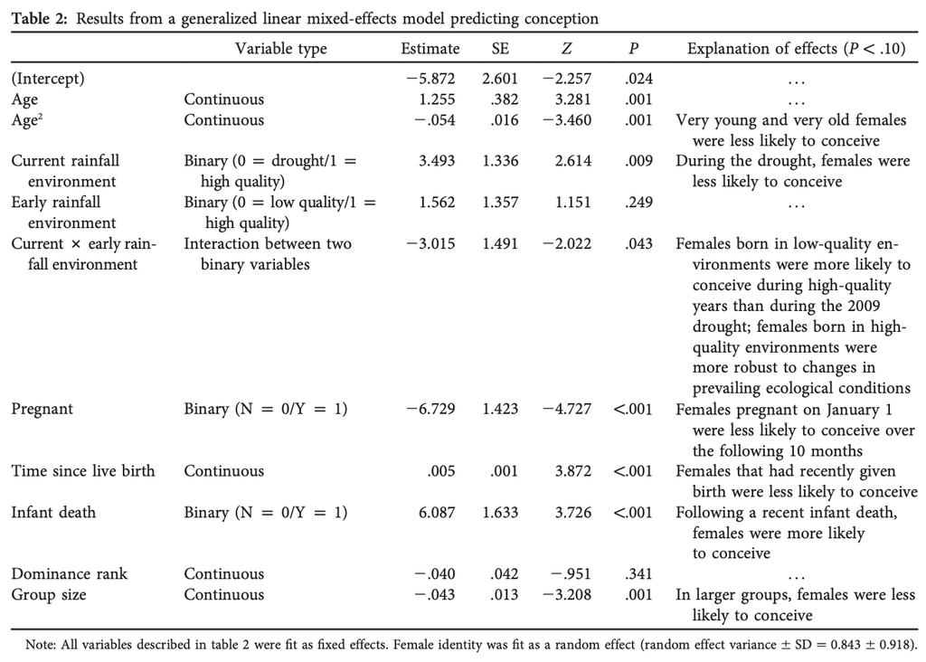

I think this may be as close as I am going to get. Everything except the Intercept, Current environment and Early environment seems to match.

LEt’s plot the residuals:

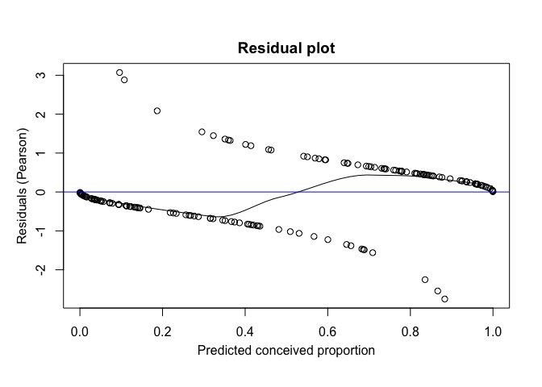

```r
scatter.smooth(fitted(glme1b), residuals(glme1b, type = "pearson"),
     mgp = c(2.2, 1, 0),
     ylab = "Residuals (Pearson)",
     xlab = "Predicted conceived proportion")
title("Residual plot", line = 0.7)
abline(h = 0, col="blue")
```

Well this is definately concerning. We shouldnt see a pattern in our residuals but maybe this has to do with the fact that we have a binary response variable.

```r
library(car)
Anova(glme1b)
```

```
## Analysis of Deviance Table (Type II Wald chisquare tests)
##
## Response: conceived
##                                 Chisq Df Pr(>Chisq)
## early_ecology                  1.5267  1  0.2166048
## current_ecology                3.4392  1  0.0636672 .
## age                            8.4377  1  0.0036752 **
## I(age^2)                       8.9953  1  0.0027067 **
## rank                           0.9627  1  0.3265115
## grp_size                       7.8436  1  0.0051002 **
## time_since_birth              11.6669  1  0.0006362 ***
## infant_death                  13.7139  1  0.0002129 ***
## preg_at_start                 19.1047  1  1.237e-05 ***
## early_ecology:current_ecology  4.0606  1  0.0438952 *
## ---
## Signif. codes:  0 '***' 0.001 '**' 0.01 '*' 0.05 '.' 0.1 ' ' 1
```

Now lets do the same with resumption of cycling as the binary outcome:

```r
glme2 <- glmer(data = d, resumed_cycling ~ early_ecology + current_ecology + age + I(age^2) + rank + grp_size + time_since_birth + infant_death + cycling_at_start + (early_ecology * current_ecology) + (1|ID), family=binomial(link = "logit"))
```

```
## boundary (singular) fit: see ?isSingular
```

```r
summary(glme2)
```

```
## Generalized linear mixed model fit by maximum likelihood (Laplace
##   Approximation) [glmerMod]
##  Family: binomial  ( logit )
## Formula:
## resumed_cycling ~ early_ecology + current_ecology + age + I(age^2) +
##     rank + grp_size + time_since_birth + infant_death + cycling_at_start +
##     (early_ecology * current_ecology) + (1 | ID)
##    Data: d
##
##      AIC      BIC   logLik deviance df.resid
##    217.7    255.4    -96.8    193.7      160
##
## Scaled residuals:
##     Min      1Q  Median      3Q     Max
## -2.4463 -0.7460 -0.2726  0.7900  2.8725
##
## Random effects:
##  Groups Name        Variance  Std.Dev.
##  ID     (Intercept) 1.792e-16 1.339e-08
## Number of obs: 172, groups:  ID, 50
##
## Fixed effects:
##                                    Estimate Std. Error z value Pr(>|z|)
## (Intercept)                        2.009179   1.740096   1.155 0.248239
## early_ecologyLQ                   -0.785104   0.787187  -0.997 0.318592
## current_ecologyHQ                  0.883606   0.508766   1.737 0.082429
## age                               -0.348614   0.252092  -1.383 0.166701
## I(age^2)                           0.014641   0.009833   1.489 0.136501
## rank                               0.018726   0.029787   0.629 0.529567
## grp_size                          -0.005631   0.008893  -0.633 0.526627
## time_since_birth                  -0.003001   0.001129  -2.658 0.007862
## infant_deathY                      0.722046   0.598825   1.206 0.227906
## cycling_at_start                  -1.619774   0.483240  -3.352 0.000803
## early_ecologyLQ:current_ecologyHQ  1.695348   0.933050   1.817 0.069218
##
## (Intercept)
## early_ecologyLQ
## current_ecologyHQ                 .
## age
## I(age^2)
```

[output cut: 19 more lines]

```
## cyclng_t_st -0.058  0.061 -0.123  0.100 -0.113 -0.023 -0.003 -0.174 -0.170
## erly_LQ:_HQ  0.139 -0.852 -0.468 -0.009  0.021  0.070 -0.103 -0.060  0.047
##             cycl__
## erly_clgyLQ
## crrnt_clgHQ
## age
## I(age^2)
## rank
## grp_size
## tm_snc_brth
## infant_dthY
## cyclng_t_st
## erly_LQ:_HQ -0.172
## convergence code: 0
## boundary (singular) fit: see ?isSingular
```

```r
tidy(glme2)
```

```
## # A tibble: 12 x 6
##    term                         estimate std.error statistic  p.value group
##    <chr>                           <dbl>     <dbl>     <dbl>    <dbl> <chr>
##  1 (Intercept)                   2.01e+0   1.74        1.15   2.48e-1 fixed
##  2 early_ecologyLQ              -7.85e-1   0.787      -0.997  3.19e-1 fixed
##  3 current_ecologyHQ             8.84e-1   0.509       1.74   8.24e-2 fixed
##  4 age                          -3.49e-1   0.252      -1.38   1.67e-1 fixed
##  5 I(age^2)                      1.46e-2   0.00983     1.49   1.37e-1 fixed
##  6 rank                          1.87e-2   0.0298      0.629  5.30e-1 fixed
##  7 grp_size                     -5.63e-3   0.00889    -0.633  5.27e-1 fixed
##  8 time_since_birth             -3.00e-3   0.00113    -2.66   7.86e-3 fixed
##  9 infant_deathY                 7.22e-1   0.599       1.21   2.28e-1 fixed
## 10 cycling_at_start             -1.62e+0   0.483      -3.35   8.03e-4 fixed
## 11 early_ecologyLQ:current…      1.70e+0   0.933       1.82   6.92e-2 fixed
## 12 sd_(Intercept).ID             1.34e-8  NA          NA     NA       ID
```

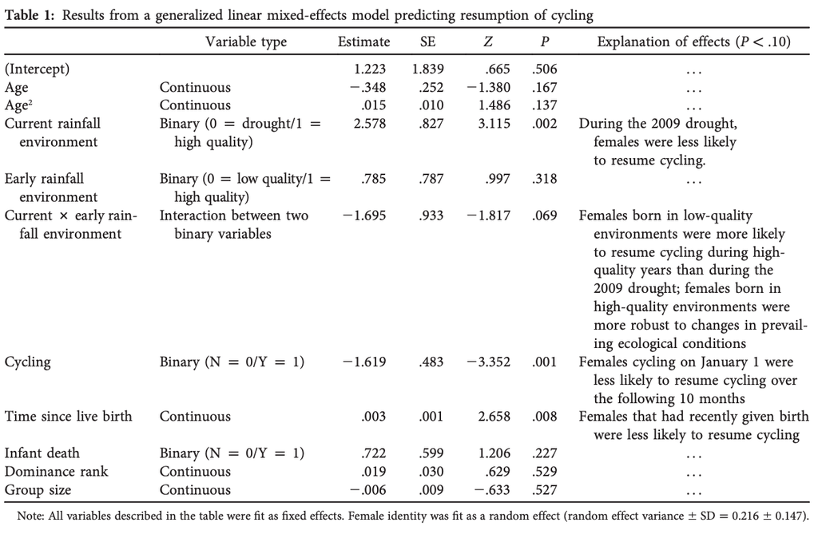

Got very close with this one as well, but its not an exact replication.

LEt’s plot the residuals:

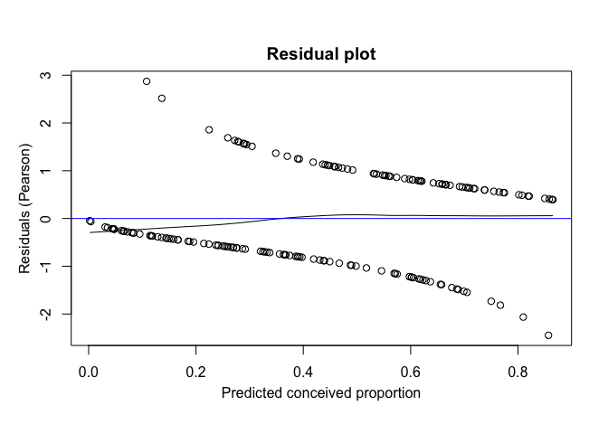

```r
scatter.smooth(fitted(glme2), residuals(glme2, type = "pearson"),
     mgp = c(2.2, 1, 0),
     ylab = "Residuals (Pearson)",
     xlab = "Predicted conceived proportion")
title("Residual plot", line = 0.7)
abline(h = 0, col="blue")
```

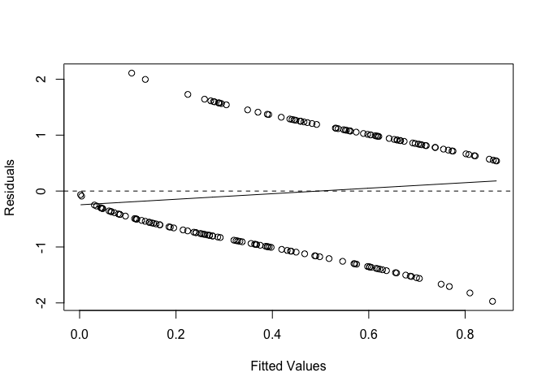

```r
plot(fitted(glme2), residuals(glme2),xlab ="Fitted Values", ylab = "Residuals")
  abline(h=0, lty=2)
  lines(smooth.spline(fitted(glme2), residuals(glme2)))
```

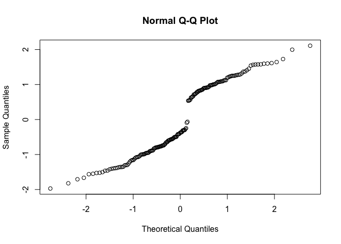

```r
qqnorm(residuals(glme2))
```

```r
Anova(glme2)
```

```
## Analysis of Deviance Table (Type II Wald chisquare tests)
##
## Response: resumed_cycling
##                                 Chisq Df Pr(>Chisq)
## early_ecology                  1.1008  1  0.2940834
## current_ecology                8.5685  1  0.0034202 **
## age                            1.9124  1  0.1667012
## I(age^2)                       2.2170  1  0.1365006
## rank                           0.3952  1  0.5295673
## grp_size                       0.4009  1  0.5266269
## time_since_birth               7.0646  1  0.0078623 **
## infant_death                   1.4539  1  0.2279063
## cycling_at_start              11.2352  1  0.0008026 ***
## early_ecology:current_ecology  3.3015  1  0.0692177 .
## ---
## Signif. codes:  0 '***' 0.001 '**' 0.01 '*' 0.05 '.' 0.1 ' ' 1
```

### Effects of Maternal Dominance Rank on Female Fertility:

The authors also tested whether inherited social status had an effect on fertility. To test this they used the residuals from the generalized linear mixed models in the previous section to conduct a linear model that asked if maternal rank was correlated with maternal dominace rank. Unfortunately, I could not firgure out how they did this. But, I think I found a work around that might get at the same question.

Instead of comparing the residuals to rank. I am going to compare models which both include and omit maternal rank as a fixed effect. I will compare each model to the null and which ever returns a lower p value will be the winner.

first we need to exclude individuals born in high quality environments from our dataset.

```r
newdata <- d[ which(d$early_ecology=='LQ'), ]
newdata
```

```
##      ID maternal_rank early_ecology current_ecology   age rank grp_size
## 60   39             4            LQ              HQ 16.18   11       59
## 61   39             4            LQ              HQ 17.18   12       66
## 62   39             4            LQ              HQ 19.18   15       73
## 63   39             4            LQ               D 23.19   17      105
## 64   39             4            LQ              HQ  6.17    9       55
## 65   39             4            LQ              HQ  8.18    8       72
## 66   39             4            LQ              HQ 13.18    7       41
## 70   41             8            LQ              HQ  6.21   11       66
## 71   41             8            LQ              HQ  8.21   14       73
## 72   41             8            LQ               D 12.21   12      105
## 73   41             8            LQ              HQ 14.21   15      113
## 87   51             7            LQ               D  9.48   19      105
## 88   51             7            LQ              HQ 11.48   18      113
## 89   53            12            LQ               D  9.46   15       57
```

[output cut: 129 more lines]

Then we build our models, starting with conception as our response variable.

No Maternal rank:

```r
glme1c <- glmer(data = newdata, conceived ~ current_ecology + age + I(age^2) + rank + grp_size + time_since_birth + infant_death + preg_at_start + (1|ID), family=binomial(link = "logit"))
summary(glme1c)
```

```
## Generalized linear mixed model fit by maximum likelihood (Laplace
##   Approximation) [glmerMod]
##  Family: binomial  ( logit )
## Formula: conceived ~ current_ecology + age + I(age^2) + rank + grp_size +
##     time_since_birth + infant_death + preg_at_start + (1 | ID)
##    Data: newdata
##
##      AIC      BIC   logLik deviance df.resid
##     41.8     60.3    -10.9     21.8       37
##
## Scaled residuals:
##     Min      1Q  Median      3Q     Max
## -0.1291  0.0000  0.0000  0.0000  0.1016
##
## Random effects:
##  Groups Name        Variance Std.Dev.
##  ID     (Intercept) 4000     63.24
## Number of obs: 47, groups:  ID, 14
##
## Fixed effects:
##                     Estimate Std. Error z value Pr(>|z|)
## (Intercept)       -1.445e+02  1.546e+03  -0.093    0.926
## current_ecologyHQ  4.335e+01  2.622e+02   0.165    0.869
## age                3.842e+01  2.431e+02   0.158    0.874
## I(age^2)          -1.449e+00  1.359e+01  -0.107    0.915
## rank               4.981e-01  2.119e+01   0.024    0.981
## grp_size          -1.633e+00  7.666e+00  -0.213    0.831
## time_since_birth   1.494e-01  1.528e+00   0.098    0.922
## infant_deathY      7.244e+03  2.769e+07   0.000    1.000
## preg_at_startY    -7.219e+03  2.590e+07   0.000    1.000
##
## Correlation of Fixed Effects:
##             (Intr) crr_HQ age    I(g^2) rank   grp_sz tm_sn_ infn_Y
## crrnt_clgHQ -0.623
## age         -0.979  0.497
## I(age^2)     0.985 -0.502 -0.997
## rank         0.936 -0.472 -0.930  0.932
## grp_size    -0.952  0.483  0.923 -0.945 -0.940
## tm_snc_brth -0.774  0.411  0.697 -0.732 -0.805  0.841
## infant_dthY  0.000  0.000  0.000  0.000  0.000  0.000  0.000
## prg_t_strtY  0.000  0.000  0.000  0.000  0.000  0.000  0.000 -0.401
## convergence code: 0
## unable to evaluate scaled gradient
## Model failed to converge: degenerate  Hessian with 1 negative eigenvalues
```

with maternal rank:

```r
glme1d <- glmer(data = newdata, conceived ~ current_ecology + age + I(age^2) + rank + grp_size + time_since_birth + infant_death + preg_at_start + maternal_rank + (1|ID), family=binomial(link = "logit"))
summary(glme1c)
```

[output not shown]

Null model:

```r
glme1e <- glmer(data = newdata, conceived ~  (1|ID), family=binomial(link = "logit"))
```

```
## boundary (singular) fit: see ?isSingular
```

```r
summary(glme1e)
```

```
## Generalized linear mixed model fit by maximum likelihood (Laplace
##   Approximation) [glmerMod]
##  Family: binomial  ( logit )
## Formula: conceived ~ (1 | ID)
##    Data: newdata
##
##      AIC      BIC   logLik deviance df.resid
##     68.6     72.3    -32.3     64.6       45
##
## Scaled residuals:
##     Min      1Q  Median      3Q     Max
## -1.1127 -1.1127  0.8987  0.8987  0.8987
##
## Random effects:
##  Groups Name        Variance Std.Dev.
##  ID     (Intercept) 0        0
## Number of obs: 47, groups:  ID, 14
##
## Fixed effects:
##             Estimate Std. Error z value Pr(>|z|)
## (Intercept)   0.2136     0.2934   0.728    0.467
## convergence code: 0
## boundary (singular) fit: see ?isSingular
```

Fit check

null vs no maternal rank

```r
anova(glme1e,glme1c)
```

```
## Data: newdata
## Models:
## glme1e: conceived ~ (1 | ID)
## glme1c: conceived ~ current_ecology + age + I(age^2) + rank + grp_size +
## glme1c:     time_since_birth + infant_death + preg_at_start + (1 | ID)
##        Df    AIC    BIC  logLik deviance  Chisq Chi Df Pr(>Chisq)
## glme1e  2 68.623 72.323 -32.311   64.623
## glme1c 10 41.821 60.323 -10.911   21.821 42.801      8  9.574e-07 ***
## ---
## Signif. codes:  0 '***' 0.001 '**' 0.01 '*' 0.05 '.' 0.1 ' ' 1
```

null vs maternal rank included

```r
anova(glme1e,glme1d)
```

```
## Data: newdata
## Models:
## glme1e: conceived ~ (1 | ID)
## glme1d: conceived ~ current_ecology + age + I(age^2) + rank + grp_size +
## glme1d:     time_since_birth + infant_death + preg_at_start + maternal_rank +
## glme1d:     (1 | ID)
##        Df    AIC    BIC  logLik deviance  Chisq Chi Df Pr(>Chisq)
## glme1e  2 68.623 72.323 -32.311   64.623
## glme1d 11 48.707 69.059 -13.353   26.707 37.916      9  1.805e-05 ***
## ---
## Signif. codes:  0 '***' 0.001 '**' 0.01 '*' 0.05 '.' 0.1 ' ' 1
```

Model **glmer1c** seems to be a better fit which means maternal rank is not affecting the probablity of conceiving in females which were born in adverse conditions. However this is the opposite of what they got so I think my work around is a failure.

And now again with the cycling response variable:

```r
glme2a <- glmer(data = newdata, resumed_cycling ~ current_ecology + age + I(age^2) + rank + grp_size + time_since_birth + infant_death + cycling_at_start + (1|ID), family=binomial(link = "logit"))
```

```
## boundary (singular) fit: see ?isSingular
```

```r
summary(glme2a)
```

```
## Generalized linear mixed model fit by maximum likelihood (Laplace
##   Approximation) [glmerMod]
##  Family: binomial  ( logit )
## Formula:
## resumed_cycling ~ current_ecology + age + I(age^2) + rank + grp_size +
##     time_since_birth + infant_death + cycling_at_start + (1 |      ID)
##    Data: newdata
##
##      AIC      BIC   logLik deviance df.resid
##     58.6     77.1    -19.3     38.6       37
##
## Scaled residuals:
##     Min      1Q  Median      3Q     Max
## -4.7588 -0.4711 -0.1839  0.5054  3.0131
##
## Random effects:
##  Groups Name        Variance Std.Dev.
##  ID     (Intercept) 0        0
## Number of obs: 47, groups:  ID, 14
##
## Fixed effects:
##                    Estimate Std. Error z value Pr(>|z|)
## (Intercept)        2.314414   4.362221   0.531  0.59572
## current_ecologyHQ  3.821682   1.279995   2.986  0.00283 **
## age               -1.055354   0.712559  -1.481  0.13859
## I(age^2)           0.049678   0.029747   1.670  0.09491 .
## rank              -0.087632   0.073983  -1.185  0.23622
## grp_size           0.033595   0.022810   1.473  0.14081
## time_since_birth  -0.004874   0.002949  -1.653  0.09838 .
## infant_deathY      0.385395   1.045922   0.368  0.71252
## cycling_at_start  -2.445519   1.024244  -2.388  0.01696 *
## ---
## Signif. codes:  0 '***' 0.001 '**' 0.01 '*' 0.05 '.' 0.1 ' ' 1
##
## Correlation of Fixed Effects:
##             (Intr) crr_HQ age    I(g^2) rank   grp_sz tm_sn_ infn_Y
## crrnt_clgHQ -0.199
## age         -0.878 -0.091
## I(age^2)     0.831  0.123 -0.981
## rank         0.008 -0.440  0.149 -0.183
## grp_size    -0.202  0.470 -0.203  0.217 -0.610
## tm_snc_brth -0.330 -0.242  0.227 -0.246  0.106  0.098
## infant_dthY  0.101 -0.051 -0.049  0.014  0.202 -0.175 -0.203
## cyclng_t_st  0.041 -0.509  0.072 -0.103  0.386 -0.301  0.050 -0.052
## convergence code: 0
## boundary (singular) fit: see ?isSingular
```

```r
glme2b <- glmer(data = newdata, resumed_cycling ~ current_ecology + age + I(age^2) + rank + grp_size + time_since_birth + infant_death + cycling_at_start + maternal_rank + (1|ID), family=binomial(link = "logit"))
```

```
## boundary (singular) fit: see ?isSingular
```

```r
summary(glme2b)
```

```
## Generalized linear mixed model fit by maximum likelihood (Laplace
##   Approximation) [glmerMod]
##  Family: binomial  ( logit )
## Formula:
## resumed_cycling ~ current_ecology + age + I(age^2) + rank + grp_size +
##     time_since_birth + infant_death + cycling_at_start + maternal_rank +
##     (1 | ID)
##    Data: newdata
##
##      AIC      BIC   logLik deviance df.resid
##     60.6     80.9    -19.3     38.6       36
##
## Scaled residuals:
##     Min      1Q  Median      3Q     Max
## -4.8092 -0.4753 -0.1817  0.4952  3.0647
##
## Random effects:
##  Groups Name        Variance  Std.Dev.
##  ID     (Intercept) 2.348e-15 4.845e-08
## Number of obs: 47, groups:  ID, 14
##
## Fixed effects:
##                    Estimate Std. Error z value Pr(>|z|)
## (Intercept)        2.340967   4.382860   0.534  0.59326
## current_ecologyHQ  3.820914   1.279411   2.986  0.00282 **
## age               -1.045796   0.719754  -1.453  0.14623
## I(age^2)           0.049174   0.030180   1.629  0.10324
## rank              -0.080159   0.108017  -0.742  0.45803
## grp_size           0.032873   0.023995   1.370  0.17069
## time_since_birth  -0.004841   0.002976  -1.627  0.10382
## infant_deathY      0.368447   1.062410   0.347  0.72874
## cycling_at_start  -2.452730   1.027860  -2.386  0.01702 *
## maternal_rank     -0.018616   0.197415  -0.094  0.92487
## ---
## Signif. codes:  0 '***' 0.001 '**' 0.01 '*' 0.05 '.' 0.1 ' ' 1
##
## Correlation of Fixed Effects:
##             (Intr) crr_HQ age    I(g^2) rank   grp_sz tm_sn_ infn_Y cycl__
## crrnt_clgHQ -0.199
## age         -0.860 -0.088
## I(age^2)     0.806  0.119 -0.981
## rank         0.048 -0.291  0.203 -0.251
## grp_size    -0.213  0.445 -0.231  0.254 -0.621
## tm_snc_brth -0.323 -0.241  0.243 -0.264  0.156  0.056
## infant_dthY  0.089 -0.049 -0.073  0.044  0.011 -0.109 -0.219
## cyclng_t_st  0.038 -0.506  0.057 -0.083  0.201 -0.259  0.038 -0.039
## maternl_rnk -0.058 -0.008 -0.142  0.177 -0.730  0.311 -0.114  0.170  0.084
## convergence code: 0
## boundary (singular) fit: see ?isSingular
```

```r
glme2c <- glmer(data = newdata, resumed_cycling ~ (1|ID), family=binomial(link = "logit"))
```

```
## boundary (singular) fit: see ?isSingular
```

```r
summary(glme2c)
```

```
## Generalized linear mixed model fit by maximum likelihood (Laplace
##   Approximation) [glmerMod]
##  Family: binomial  ( logit )
## Formula: resumed_cycling ~ (1 | ID)
##    Data: newdata
##
##      AIC      BIC   logLik deviance df.resid
##     69.1     72.8    -32.6     65.1       45
##
## Scaled residuals:
##     Min      1Q  Median      3Q     Max
## -0.9789 -0.9789 -0.9789  1.0215  1.0215
##
## Random effects:
##  Groups Name        Variance Std.Dev.
##  ID     (Intercept) 0        0
## Number of obs: 47, groups:  ID, 14
##
## Fixed effects:
##             Estimate Std. Error z value Pr(>|z|)
## (Intercept) -0.04256    0.29180  -0.146    0.884
## convergence code: 0
## boundary (singular) fit: see ?isSingular
```

```r
anova(glme2c,glme2a)
```

```
## Data: newdata
## Models:
## glme2c: resumed_cycling ~ (1 | ID)
## glme2a: resumed_cycling ~ current_ecology + age + I(age^2) + rank + grp_size +
## glme2a:     time_since_birth + infant_death + cycling_at_start + (1 |
## glme2a:     ID)
##        Df    AIC    BIC  logLik deviance  Chisq Chi Df Pr(>Chisq)
## glme2c  2 69.135 72.835 -32.567   65.135
## glme2a 10 58.580 77.081 -19.290   38.580 26.555      8  0.0008436 ***
## ---
## Signif. codes:  0 '***' 0.001 '**' 0.01 '*' 0.05 '.' 0.1 ' ' 1
```

```r
anova(glme2c,glme2b)
```

```
## Data: newdata
## Models:
## glme2c: resumed_cycling ~ (1 | ID)
## glme2b: resumed_cycling ~ current_ecology + age + I(age^2) + rank + grp_size +
## glme2b:     time_since_birth + infant_death + cycling_at_start + maternal_rank +
## glme2b:     (1 | ID)
##        Df    AIC    BIC  logLik deviance  Chisq Chi Df Pr(>Chisq)
## glme2c  2 69.135 72.835 -32.567   65.135
## glme2b 11 60.571 80.923 -19.285   38.571 26.564      9   0.001651 **
## ---
## Signif. codes:  0 '***' 0.001 '**' 0.01 '*' 0.05 '.' 0.1 ' ' 1
```

So it appears that model **glme2a** which does not include maternal rank is a better fit which means that maternal rank may not be a factor in the resumption of cycle of females which where born in poor conditions. Again, this is the opposite of what we expected based on the papers results.

one last ditch effort:

Let’s see what the residuals look like:

```r
res <- residuals(glme1b)
res
```

[output not shown]

Let’s look at the maternal ranks for the females inour new dataset:

```r
rank <- newdata$maternal_rank
rank
```

```
##  [1]  4  4  4  4  4  4  4  8  8  8  8  7  7 12 12 10 10 11 11  9  9  1  1
## [24]  1  1  1  1  1  5  5  5  5  5  5  2  2  2  2  2  1  1  4  4  4  3  3
## [47]  3
```

I am certain there is a way to put all of these together in r but I can’t figure it out at the moment. I will just make a csv manually.

And now to load in:

```r
library(curl)
z <- curl("https://raw.githubusercontent.com/cmgagnon/cmgagnon-data-replication-assignment/master/residuals_maternal_rank_matrix.csv")
x <- read.csv(z, header = TRUE, sep = ",", stringsAsFactors = TRUE)
head(x)
```

```
##   residuals maternal_ranks
## 1     0.149              4
## 2     0.611              4
## 3     0.240              4
## 4    -0.219              4
## 5     0.500              4
## 6     0.189              4
```

```r
str(x)
```

```
## 'data.frame':    47 obs. of  2 variables:
##  $ residuals     : num  1.49e-01 6.11e-01 2.40e-01 -2.19e-01 5.00e-01 1.89e-01 6.39e-02 4.21e-01 8.60e-01 -9.27e-07 ...
##  $ maternal_ranks: int  4 4 4 4 4 4 4 8 8 8 ...
```

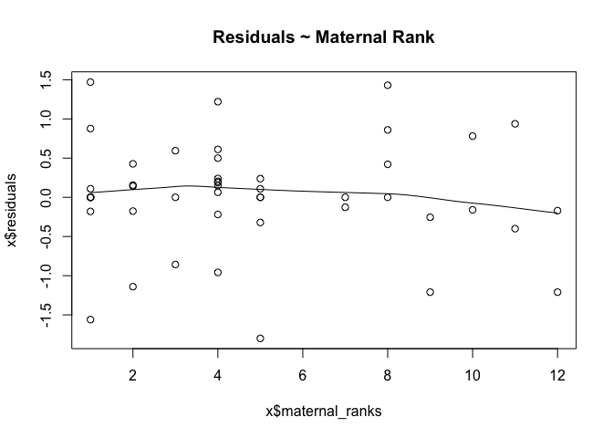

```r
scatter.smooth(x=x$maternal_ranks, y=x$residuals, main="Residuals ~ Maternal Rank")
```

looks nothing like it. Maybe I am using the residuals from the wrong models. I changed the residual to the one from the glmer model we did in the last section.

```r
library(curl)
q <- curl("https://raw.githubusercontent.com/cmgagnon/cmgagnon-data-replication-assignment/master/residuals_maternal_rank_matrix2.csv")
r <- read.csv(z, header = TRUE, sep = ",", stringsAsFactors = TRUE)
head(r)
```

[output not shown]

```r
str(r)
```

[output not shown]

Let’s try to plot this:

[figure not shown]

```r
scatter.smooth(x=r$maternal_ranks, y=r$residuals, main="Residuals ~ Maternal Rank")
```

Nope! still lokks nothing like it.

```r
library(curl)
i <- curl("https://raw.githubusercontent.com/cmgagnon/cmgagnon-data-replication-assignment/master/residuals_maternal_rank_matrix3.csv")
h <- read.csv(i, header = TRUE, sep = ",", stringsAsFactors = TRUE)
head(h)
```

```
##   ID   residuals maternal_ranks
## 1 39  0.29669748              4
## 2 39  0.79210843              4
## 3 39  1.02245557              4
## 4 39 -0.03022737              4
## 5 39  0.52736010              4
## 6 39  0.28667315              4
```

```r
str(h)
```

```
## 'data.frame':    47 obs. of  3 variables:
##  $ ID            : int  39 39 39 39 39 39 39 41 41 41 ...
##  $ residuals     : num  0.2967 0.7921 1.0225 -0.0302 0.5274 ...
##  $ maternal_ranks: int  4 4 4 4 4 4 4 8 8 8 ...
```

```r
library(dplyr)
zz <- data.frame(h)
zz
```

```
##     ID   residuals maternal_ranks
## 1   39  0.29669748              4
## 2   39  0.79210843              4
## 3   39  1.02245557              4
## 4   39 -0.03022737              4
## 5   39  0.52736010              4
## 6   39  0.28667315              4
## 7   39  0.11575350              4
## 8   41  1.24133687              8
## 9   41 -1.52711943              8
## 10  41 -0.87069647              8
## 11  41  0.46812797              8
## 12  51  0.60959143              7
## 13  51 -0.03510654              7
## 14  53  1.04589815             12
```

[output cut: 33 more lines]

```r
lm1 <- lm(residuals ~ maternal_ranks + (1|ID),zz)
tidy(lm1)
```

```
## # A tibble: 2 x 5
##   term           estimate std.error statistic p.value
##   <chr>             <dbl>     <dbl>     <dbl>   <dbl>
## 1 (Intercept)     -0.195     0.217     -0.899   0.373
## 2 maternal_ranks   0.0414    0.0370     1.12    0.269
```

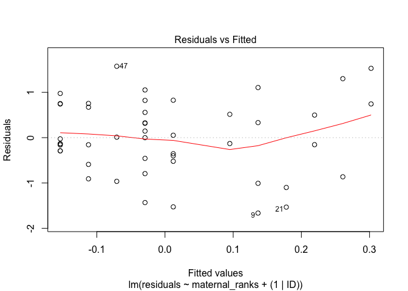

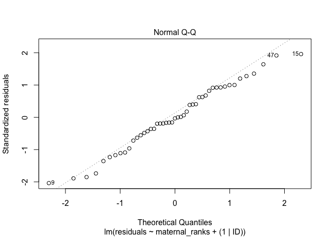

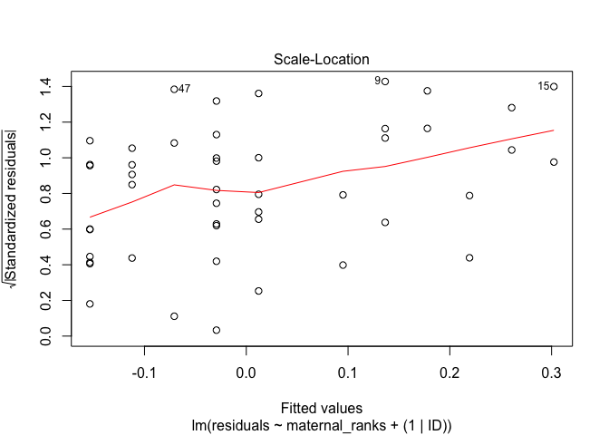

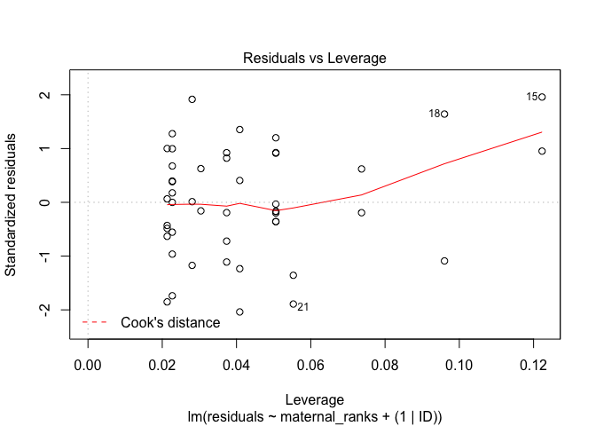

```r
plot(lm1)
```

Getting this error: Error in as.data.frame.default(data) : cannot coerce class ‘“formula”’ to a data.frame

```r
#d$maternal_rank <- as.numeric(as.character(d$maternal_rank))

#res <- residuals(glme1d)

#lm1 <- lm(res, m$ ~d$maternal_rank)
```

## Discussion

According to my somewhat replicated results, the conclusions put forth by the authors appear reasonable. Individuals subjected to poor quality environments do not appear to out-reproduce others when faced with similar conditions after reaching sexual maturity. Instead, the data supports the developmental constraint hypothesis as female born low quality settings show reduced reproductive success. No matter how hard I tried I was not able to replicate the results for the effect of maternal rank on future fertility. Everything I tried gsve me the opposite result. I was a little out of my depth on that one and the methids section of the paper was not super descriptive. Moral of this story, modeling can be complicated!